# Which slope should bodycon use for the scaled mass index?

bodycon development team

2026-10-02

```r
library(bodycon)
```

# Purpose of this review

This article documents an unresolved statistical and API decision in `bodycon`. It is intended for collaborator review; it does **not** propose that the package implementation be changed before the statistical definitions and public method names are agreed.

The scaled mass index (SMI) for individual $i$ can be written as

$$\widehat{M}_i = M_i \left(\frac{L_0}{L_i}\right)^b,$$

where $M_i$ is mass, $L_i$ is body size, $L_0$ is a reference body size (the sample mean in the current package), and $b$ is the estimated scaling exponent. The open question is how `bodycon` should estimate $b$.

The distinction matters because ordinary least squares (OLS), robust OLS, standardised major axis (SMA), and robust SMA solve different fitting problems. Even when the resulting slopes are similar, they should not be described as interchangeable.

# What the package currently calculates

At present, the implementation and documentation do not identify the same estimators:

1. `bci_smi_ols()` fits `lm(log_mass ~ log_size)`, but does not use that fitted model. Its returned SMI values use the slope from `smatr::sma(log_mass ~ log_size)`, whose default method is SMA.
2. `bci_smi_rob()` fits `MASS::rlm(log_mass ~ log_size)`, but does not use that fitted model. Its returned SMI values use `smatr::sma(log_mass ~ log_size, robust = TRUE)`.
3. `plot_bci()` independently uses the same classical and robust SMA slopes for its two SMI lines.

Consequently, the current output columns called `smi_ols` and `smi_rob` actually contain SMI values based on classical SMA and robust SMA, respectively. The `lm()` and `MASS::rlm()` objects are calculated but have no effect on the results.

The following helpers reproduce four candidate definitions without modifying the package.

```r
fit_candidates <- function(data, size, mass) {
  log_size <- log(data[[size]])
  log_mass <- log(data[[mass]])

  ols <- stats::lm(log_mass ~ log_size)
  robust_ols <- MASS::rlm(log_mass ~ log_size, method = "M")
  sma <- smatr::sma(
    log_mass ~ log_size,
    method = "SMA",
    robust = FALSE,
    quiet = TRUE
  )
  robust_sma <- smatr::sma(
    log_mass ~ log_size,
    method = "SMA",
    robust = TRUE,
    quiet = TRUE
  )

  data.frame(
    estimator = c("OLS", "Robust OLS (MASS::rlm)",
                  "SMA", "Robust SMA (smatr)"),
    intercept = c(
      unname(stats::coef(ols)[1]),
      unname(stats::coef(robust_ols)[1]),
      unname(stats::coef(sma)[1]),
      unname(stats::coef(robust_sma)[1])
    ),
    slope = c(
      unname(stats::coef(ols)[2]),
      unname(stats::coef(robust_ols)[2]),
      unname(stats::coef(sma)[2]),
      unname(stats::coef(robust_sma)[2])
    )
  )
}

calculate_smi <- function(data, size, mass, slope) {
  size_values <- data[[size]]
  mass_values <- data[[mass]]
  reference_size <- mean(size_values, na.rm = TRUE)

  mass_values * (reference_size / size_values)^slope
}

candidate_indices <- function(data, size, mass) {
  fits <- fit_candidates(data, size, mass)
  values <- lapply(
    fits$slope,
    function(slope) calculate_smi(data, size, mass, slope)
  )
  names(values) <- fits$estimator
  values
}
```

# Comparison using the package data

## Estimated scaling exponents

```r
snake_fits <- fit_candidates(gartersnake, "svl_mm", "mass_g")
snake_fits$dataset <- "Gartersnake"

salamander_fits <- fit_candidates(salamander, "svl_mm", "mass_g")
salamander_fits$dataset <- "Salamander"

slope_table <- rbind(snake_fits, salamander_fits)
slope_table <- slope_table[c("dataset", "estimator", "slope", "intercept")]

knitr::kable(
  slope_table,
  digits = 4,
  caption = "Candidate fits for the two bodycon datasets. Fits use natural-log mass and body size."
)
```

Candidate fits for the two bodycon datasets. Fits use natural-log mass and body size.

| dataset | estimator | slope | intercept |
| --- | --- | --- | --- |
| Gartersnake | OLS | 2.7731 | -12.7019 |
| Gartersnake | Robust OLS (MASS::rlm) | 2.7979 | -12.8585 |
| Gartersnake | SMA | 3.0792 | -14.5094 |
| Gartersnake | Robust SMA (smatr) | 2.9937 | -14.0134 |
| Salamander | OLS | 2.8404 | -10.6204 |
| Salamander | Robust OLS (MASS::rlm) | 2.8123 | -10.5013 |
| Salamander | SMA | 2.9233 | -10.9093 |
| Salamander | Robust SMA (smatr) | 2.9649 | -11.0476 |

The four slopes are not identical. For the gartersnake data, the separation between OLS and SMA is larger than the separation between classical and robust versions of either family. For the salamander data, the methods are closer, but still produce distinct exponents and hence distinct individual SMI values.

## Confirmation of current package behavior

```r
snake_indices <- candidate_indices(gartersnake, "svl_mm", "mass_g")
salamander_indices <- candidate_indices(salamander, "svl_mm", "mass_g")

current_check <- data.frame(
  dataset = c("Gartersnake", "Gartersnake", "Salamander", "Salamander"),
  package_output = c("bci_smi_ols", "bci_smi_rob",
                     "bci_smi_ols", "bci_smi_rob"),
  candidate = c("SMA", "Robust SMA (smatr)",
                "SMA", "Robust SMA (smatr)"),
  maximum_absolute_difference = c(
    max(abs(
      bci_smi_ols(gartersnake, svl_mm, mass_g)$smi_ols -
        snake_indices[["SMA"]]
    )),
    max(abs(
      bci_smi_rob(gartersnake, svl_mm, mass_g)$smi_rob -
        snake_indices[["Robust SMA (smatr)"]]
    )),
    max(abs(
      bci_smi_ols(salamander, svl_mm, mass_g)$smi_ols -
        salamander_indices[["SMA"]]
    )),
    max(abs(
      bci_smi_rob(salamander, svl_mm, mass_g)$smi_rob -
        salamander_indices[["Robust SMA (smatr)"]]
    ))
  )
)

knitr::kable(
  current_check,
  digits = 12,
  caption = "The current public functions reproduce the SMA candidates, not the fitted lm or MASS::rlm candidates."
)
```

The current public functions reproduce the SMA candidates, not the fitted lm or MASS::rlm candidates.

| dataset | package_output | candidate | maximum_absolute_difference |
| --- | --- | --- | --- |
| Gartersnake | bci_smi_ols | SMA | 0 |
| Gartersnake | bci_smi_rob | Robust SMA (smatr) | 0 |
| Salamander | bci_smi_ols | SMA | 0 |
| Salamander | bci_smi_rob | Robust SMA (smatr) | 0 |

## Effect on individual SMI values

The table below compares each candidate with classical SMA, which is the slope recommended for the original SMI formulation by Peig and Green (2009).

```r
summarise_candidates <- function(indices, dataset) {
  reference <- indices[["SMA"]]

  do.call(
    rbind,
    lapply(names(indices), function(estimator) {
      values <- indices[[estimator]]
      data.frame(
        dataset = dataset,
        estimator = estimator,
        mean_smi = mean(values, na.rm = TRUE),
        sd_smi = stats::sd(values, na.rm = TRUE),
        maximum_absolute_difference_from_sma =
          max(abs(values - reference), na.rm = TRUE),
        correlation_with_sma = stats::cor(values, reference,
                                          use = "complete.obs")
      )
    })
  )
}

index_summary <- rbind(
  summarise_candidates(snake_indices, "Gartersnake"),
  summarise_candidates(salamander_indices, "Salamander")
)

knitr::kable(
  index_summary,
  digits = 4,
  caption = "How alternative exponents change SMI values relative to classical SMA."
)
```

How alternative exponents change SMI values relative to classical SMA.

| dataset | estimator | mean_smi | sd_smi | maximum_absolute_difference_from_sma | correlation_with_sma |
| --- | --- | --- | --- | --- | --- |
| Gartersnake | OLS | 47.2912 | 20.8675 | 18.3563 | 0.9787 |
| Gartersnake | Robust OLS (MASS::rlm) | 47.3501 | 21.0055 | 17.0169 | 0.9822 |
| Gartersnake | SMA | 48.2047 | 23.1358 | 0.0000 | 1.0000 |
| Gartersnake | Robust SMA (smatr) | 47.9078 | 22.3773 | 5.5444 | 0.9985 |
| Salamander | OLS | 0.5506 | 0.1003 | 0.0512 | 0.9902 |
| Salamander | Robust OLS (MASS::rlm) | 0.5500 | 0.1001 | 0.0677 | 0.9824 |
| Salamander | SMA | 0.5525 | 0.1024 | 0.0000 | 1.0000 |
| Salamander | Robust SMA (smatr) | 0.5536 | 0.1042 | 0.0271 | 0.9976 |

High correlations do not mean that the estimators are equivalent. Differences can still affect effect sizes, rankings of similar individuals, thresholds, and downstream models. The appropriate tolerance for those changes should be considered in the context of the intended ecological analyses.

## Visual comparison of fitted relationships

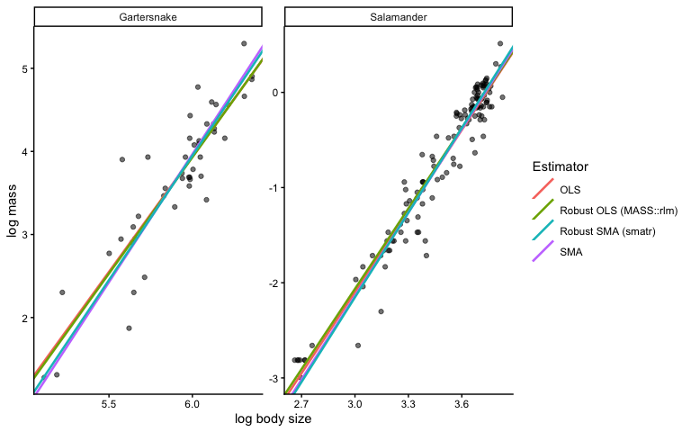

```r
plot_data <- rbind(
  data.frame(
    dataset = "Gartersnake",
    log_size = log(gartersnake$svl_mm),
    log_mass = log(gartersnake$mass_g)
  ),
  data.frame(
    dataset = "Salamander",
    log_size = log(salamander$svl_mm),
    log_mass = log(salamander$mass_g)
  )
)

line_data <- slope_table

ggplot2::ggplot(plot_data, ggplot2::aes(log_size, log_mass)) +
  ggplot2::geom_point(alpha = 0.55) +
  ggplot2::geom_abline(
    data = line_data,
    ggplot2::aes(slope = slope, intercept = intercept, colour = estimator),
    linewidth = 0.9
  ) +
  ggplot2::facet_wrap(~ dataset, scales = "free") +
  ggplot2::labs(
    x = "log body size",
    y = "log mass",
    colour = "Estimator"
  ) +
  ggplot2::theme_classic()
```

# Why robust SMA is not MASS::rlm

Both methods use M-estimation ideas, but they estimate different relationships.

`MASS::rlm(y ~ x)` is a directional robust regression. It iteratively downweights observations according to residuals in the response direction. It therefore estimates a robust conditional relationship of $y$ given $x$.

`smatr::sma(y ~ x, robust = TRUE)` first obtains a robust bivariate location and covariance estimate for $(x, y)$ using Huber M-estimation. It then derives the SMA slope from the robust variances and covariance. This treats variation in both variables as part of the fitted allometric axis.

One diagnostic of this distinction is to reverse the variables. SMA is axis-symmetric: reversing the variables and taking the reciprocal returns the same fitted slope, subject to numerical tolerance. Regression of $y$ on $x$ with `rlm()` is not generally the reciprocal of regression of $x$ on $y$.

```r
direction_check <- function(data, size, mass, dataset) {
  x <- log(data[[size]])
  y <- log(data[[mass]])

  data.frame(
    dataset = dataset,
    estimator = c("Robust OLS", "Robust SMA"),
    forward_slope = c(
      unname(stats::coef(MASS::rlm(y ~ x, method = "M"))[2]),
      unname(stats::coef(smatr::sma(
        y ~ x, method = "SMA", robust = TRUE, quiet = TRUE
      ))[2])
    ),
    reciprocal_reversed_slope = c(
      1 / unname(stats::coef(MASS::rlm(x ~ y, method = "M"))[2]),
      1 / unname(stats::coef(smatr::sma(
        x ~ y, method = "SMA", robust = TRUE, quiet = TRUE
      ))[2])
    )
  )
}

direction_table <- rbind(
  direction_check(gartersnake, "svl_mm", "mass_g", "Gartersnake"),
  direction_check(salamander, "svl_mm", "mass_g", "Salamander")
)

knitr::kable(direction_table, digits = 4)
```

| dataset | estimator | forward_slope | reciprocal_reversed_slope |
| --- | --- | --- | --- |
| Gartersnake | Robust OLS | 2.7979 | 3.3677 |
| Gartersnake | Robust SMA | 2.9937 | 2.9937 |
| Salamander | Robust OLS | 2.8123 | 2.9512 |
| Salamander | Robust SMA | 2.9649 | 2.9649 |

# Options for the package API

No option below should be implemented until the intended estimators and compatibility policy are agreed.

## Option A: document and rename the current behavior

Treat the current calculations as intentional:

- classical SMA SMI;
- robust SMA SMI using `smatr::sma(..., robust = TRUE)`.

The existing `smi_ols` terminology would need to be deprecated or explicitly described as a legacy name. This preserves numerical results but changes how the methods are presented to users.

## Option B: make the current names literal

Use the slope from `lm()` for `smi_ols` and the slope from `MASS::rlm()` for `smi_rob`. This aligns implementation with the current names and much of the documentation, but changes all existing SMI results and departs from the SMA slope used in the original SMI formulation.

## Option C: expose robust SMA as an additional method

If OLS and robust OLS are desired methods, robust SMA could still be offered as a separate package method. A possible explicit set is:

- `smi_sma`;
- `smi_sma_rob`;
- `smi_ols`;
- `smi_ols_rob` or `smi_rlm`.

This is the clearest representation of the statistical choices, but it expands the API and requires careful documentation about which methods follow the Peig-Green SMI definition and which are package extensions.

## Option D: one SMI function with an explicit slope method

Another design is a single interface such as:

```r
bci_smi(
  data,
  body_size,
  weight,
  slope_method = c("sma", "robust_sma", "ols", "robust_ols")
)
```

Existing functions could remain as compatibility wrappers. This makes the choice visible at the call site and provides one place to implement validation, missing-value behavior, and output construction.

# Should fitting arguments be accepted through …?

Passing arguments through `...` could be useful, particularly if robust SMA is made an explicit package option. For example, `smatr::sma()` exposes arguments such as `V` for a measurement-error variance matrix and `quiet`; `MASS::rlm()` has a different set, including `psi`, `scale.est`, `k2`, `maxit`, and `acc`.

A simple wrapper could technically forward dots:

```r
bci_smi_sma <- function(data, body_size, weight, robust = FALSE, ...) {
  # capture and validate data first
  smatr::sma(
    log_weight ~ log_body_size,
    data = fit_data,
    method = "SMA",
    robust = robust,
    ...
  )
}
```

However, unrestricted `...` has important risks:

- arguments valid for `smatr::sma()` are not necessarily valid for `MASS::rlm()`;
- users could attempt to override protected choices such as `formula`, `data`, `method`, `robust`, or log transformation;
- `smatr::sma(method = "OLS")` is available, but allowing `method` through would silently change the statistical definition of the index;
- some `sma()` arguments affect inference rather than the SMI slope and may create the impression that confidence intervals are being propagated to the returned index when they are not;
- backend-specific errors would become part of the public `bodycon` API.

For a single-backend function, documented `...` with validation could be reasonable. For a function that dispatches to different fitting backends, an explicit control list is safer and easier to document:

```r
bci_smi(
  data,
  body_size,
  weight,
  slope_method = "robust_sma",
  fit_control = list(quiet = TRUE)
)
```

The implementation could validate `fit_control` against an allowlist for the selected method and reject protected arguments. Separate `sma_control` and `rlm_control` arguments would be even more explicit if both backends are supported by one call.

For collaborator discussion, the key questions are:

1. Which slope estimator represents the scientific definition intended by the package?
2. Should robust SMA be the robust version of SMI, or an additional option alongside robust OLS?
3. Is backward numerical compatibility with version 0.1.0 required?
4. Should advanced fitting controls be part of the public API now, or added only after the core estimator names and defaults are stable?

# References

Peig J, Green AJ (2009). New perspectives for estimating body condition from mass/length data: the scaled mass index as an alternative method. *Oikos*, 118(12), 1883–1891.

Venables WN, Ripley BD (2002). *Modern Applied Statistics with S*, 4th ed. Springer, New York.

Warton DI, Duursma RA, Falster DS, Taskinen S (2012). smatr 3—an R package for estimation and inference about allometric lines. *Methods in Ecology and Evolution*, 3(2), 257–259.